# ensinaR

Pedro de Brito Neto

19/10/2020

# Introdução

Primeiramente vamos carregar alguns pacotes que iremos útilizar

```r
library(ggplot2)
library(dplyr)
library(janitor)
library(lubridate)
library(tidyr)
library(tidyverse)
library(ggthemes)
library(forcats)
```

Após carregar os pacotes, iremos carregar o conjunto de dados. Uma forma de ler diretamente essa informação no R pode ser feita da seguinte forma.

*dados <- read.csv(“https://bi.static.es.gov.br/covid19/MICRODADOS.csv”, sep = “;”, fileEncoding = “ISO-8859-1”)*

Outra maneira de obter a planilha é baixando ela diretamente pelo site e importando do seu computador. Nesse caso,iremos trabalhar dessa forma.  
Agora podemos começar a organizar os dados para fazermos as análises.

# Filtrando

Como queremos fazer as análises baseada nos casos confirmados, podemos começar aplicando um filtro para selecionarmos apenas os casos confirmados. Depois disso, usaremos o pacote `forcats` para mudarmos os nomes da variável “Sexo” e por último, criamos uma nova variável chama “Idade” que vai receber apenas os dois primeiros dígitos da varíavel “IdadeNaNotificacao”.

```r
dados <- read.csv("Colocar caminho onde está salvo/MICRODADOS.csv", sep = ";")
dados <- filter(dados, Classificacao == "Confirmados")

dados$Sexo <- fct_recode(dados$Sexo,
                    Masculino ="M",
                    Feminino = "F",
                    Ignorados = "I")

dados$Idade <- str_sub(dados$IdadeNaDataNotificacao, end = 2)
```

Com essas filtragens, já podemos começar a gerar alguns gráficos interessantes como, por exemplo, a quantidade de casos confirmados separados por faixa etária a quantidade de casos confirmados separados por Raça/Cor e um histograma de frequência separado por sexo. Vale ressaltar, que para gerar o histograma é necessário mudarmos a varíavel “Idade” para numeric, basta útilizar a função `as.numeric`.

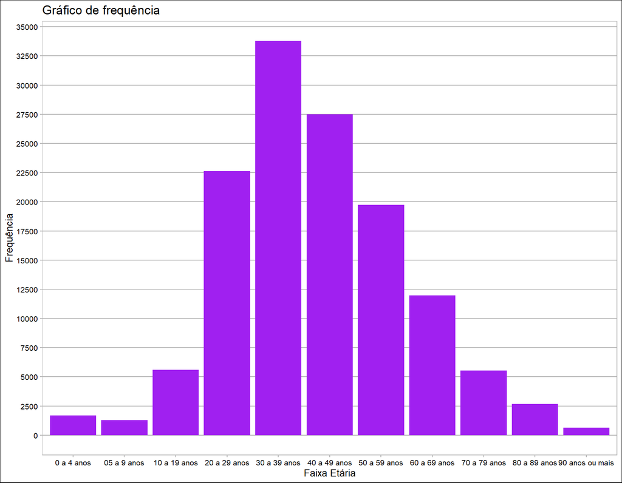

```r
ggplot(dados) +
  geom_bar(aes(x = FaixaEtaria), fill = "purple") +
  labs(y = "Frequência",
       x = "Faixa Etária",
       title = "Gráfico de frequência ") +
  scale_y_continuous(breaks = seq(0, 100000, 2500)) +
  theme_calc()
```

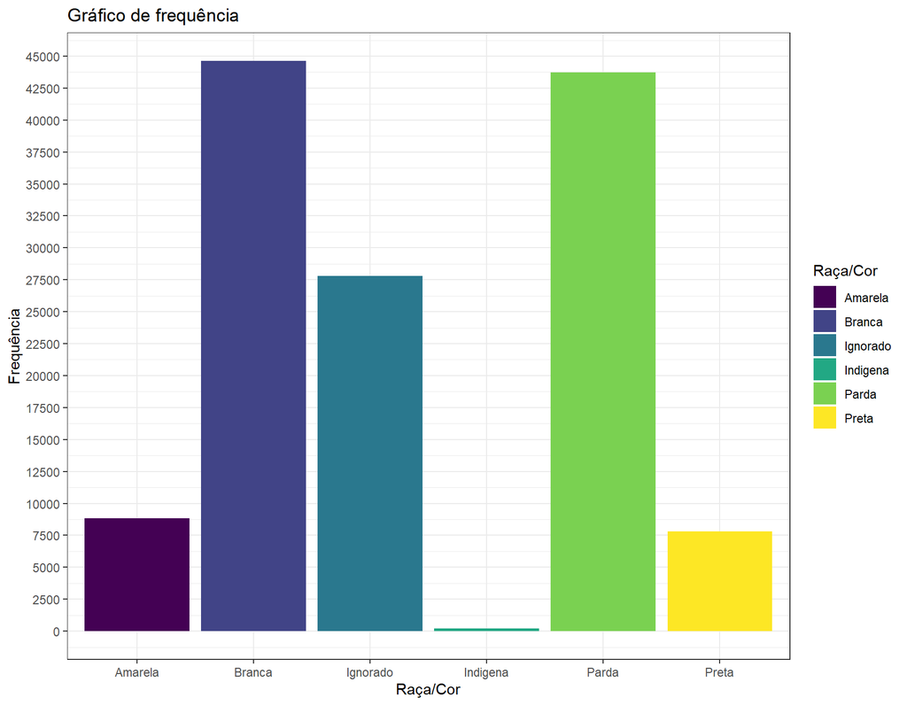

```r
ggplot(dados) +
  geom_bar(aes(x = RacaCor, fill = RacaCor)) +
  scale_y_continuous(breaks = seq(0, 100000, 2500)) +
  labs(y = "Frequência",
       x = "Raça/Cor",
       title = "Gráfico de frequência") +
  theme_bw() +
  scale_fill_viridis_d(name = "Raça/Cor")
```

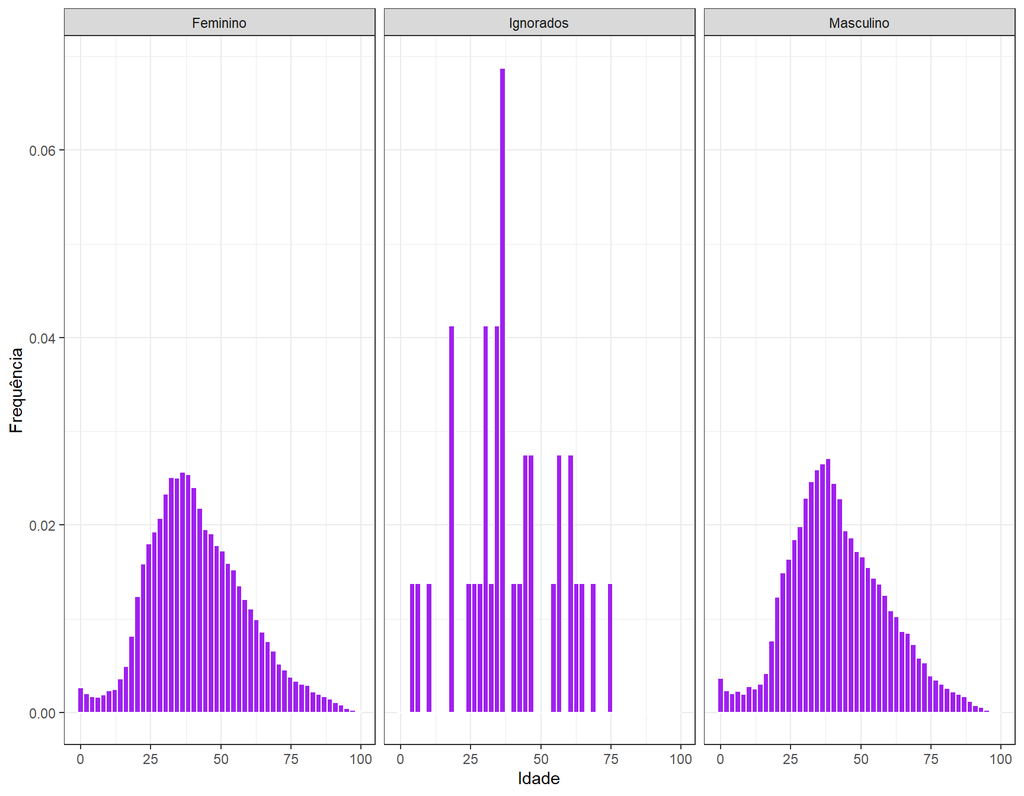

```r
dados$Idade <- as.numeric(dados$Idade)

ggplot(dados, aes(x = Idade, y = ..density..)) +
  geom_histogram(color = "white", bins = 50, fill = 'purple') +
  facet_wrap(~ Sexo) +
  theme_bw() +
  ylab("Frequência") +
  scale_fill_viridis_d()
```

Uma outra coisa interessanta a ser feita é analisarmos os casos nas regiões do Espirito Santo. Seguimos a divisão feita pelo Governo do Estado que pode ser encontra da [clicando aqui](http://www.ijsn.es.gov.br/mapas/), onde o estado foi dividido nas seguintes regiões: Metropolitana, Central, norte e sul.  
usamos uma `function` para atribuirmos cada cidade a sua devida região.

```r
regiao <- rep(nrow(dados))

classifica_regiao <- function(Municipio){
  reg_metropolitana <- c(
  'VITORIA',
  "DOMINGOS MARTINS" ,
  "SANTA LEOPOLDINA" ,
  "MARECHAL FLORIANO" ,
  'FUNDAO' ,
  'SERRA' ,
  'VILA VELHA' ,
  'CARIACICA' ,
  'VIANA' ,
  'GUARAPARI' ,
  "SANTA LEOPOLDINA" ,
  "DOMIGOS MARTINS" ,
  "MARCHAL FLORIANO" ,
  "SANTA TERESA" ,
  "SANTA MARIA DO JETIBA" ,
  "ITAGUACU" ,
  "LARANJA DA TERRA" ,
  "ITARANA" ,
  "AFONSO CLAUDIO" ,
  "VENDA NOVA DO IMIGRANDE" ,
  "BREJETUBA" ,
  "CONCEICAO DO CASTELO"
 )
  reg_norte <- c(
    "AGUIA BRANCA " ,
    "VENDA NOVA DO IMIGRANTE" ,
    "SANTA MARIA DE JETIBA" ,
    "MANTENOPOLIS" ,
    "JAGUARE" ,
    "SAO MATEUS" ,
    "NOVA VENECIA" ,
    "BARRA DE SAO FRANCISCO" ,
    "VILA PAVAO" ,
    "BOA ESPERANCA" ,
    "AGUA DOCE DO NORTE" ,
    "CONCEICAO DA BARRA" ,
    "PINHEIROS" ,
    "PEDRO CANARIO" ,
    "MONTANHA" ,
    "MUCURICI" ,
    "PONTO BELO" ,
    "ECOPORANGA"
  )

  reg_central <- c(
    "ARACRUZ" ,
    "IBIRACU" ,
    "JOAO NEIVA" ,
    "SAO ROQUE DO CANAA" ,
    "BAIXO GUANDU" ,
    "COLATINA" ,
    "MARILANDIA" ,
    "LINHARES" ,
    "RIO BANANAL" ,
    "PANCAS" ,
    "SOORETAMA" ,
    "GOVERNADOR LINDENBERG" ,
    "SAO DOMINGOS DO NORTE" ,
    "ALTO RIO NOVO" ,
    "SAO GABRIEL DA PALHA" ,
    "VILA VALERIO"
  )

  reg_sul <- c(
    'PRESIDENTE KENNEDY'    ,
    "MUQUI" ,
    'MARATAIZES'    ,
    'ITAPEMIRIM'    ,
    'MIMOSO DO SUL' ,
    'APIACA' ,
    'BOM JESUS DO NORTE' ,
    'SAO JOSE DO CALCADO' ,
    "MUQI" ,
    "ATILIO VIVACQUA" ,
    "PIUMA " ,
    "RIO NOVO DO SUL" ,
    "CACHOEIRO DE ITAPEMIRIM" ,
    "JERONIMO MONTEIRO" ,
    "ALEGRE" ,
    "GUACUI" ,
    "DORES DO RIO PRETO" ,
    "DIVINO DE SAO LOURENCO" ,
    "IBITIRAMA" ,
    "IUNA" ,
    "IBATIBA" ,
    "IRUPI" ,
    "MUNIZ FREIRE" ,
    "CASTELO" ,
    "VARGEM ALTA" ,
    "ALFREDO CHAVES" ,
    "ANCHIETA" ,
    "ICONHA" ,
    "RIO NOVO DO SUL" ,
    "PIUMA" ,
    "ICONHA"
  )

  regiao <-
    ifelse(any(Municipio == reg_metropolitana),
           "Região Metropolitana",
           ifelse(any(Municipio == reg_norte),
                  "Região Norte",
                  ifelse(any(Municipio == reg_central),
                         "Região Central",
                         ifelse(any(Municipio == reg_sul),
                                "Região Sul", "Outro Estado")
                         )
                  )
           )
  return(regiao)

}

dados$regiao <- sapply(dados$Municipio, classifica_regiao)
```

Pronto, agora conseguiremos ver de uma forma clara a quantidade de casos em casa região

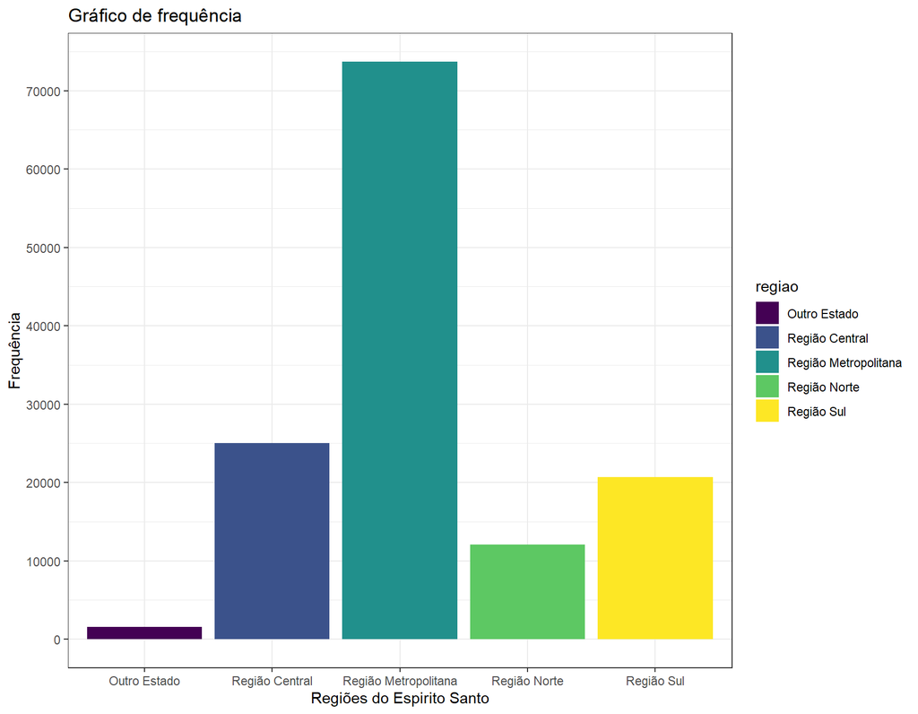

```r
ggplot(dados) + geom_bar(aes(x = regiao, fill = regiao)) +
  scale_y_continuous(breaks = seq(0, 100000, 10000)) +
  labs(y = "Frequência",
       x = "Regiões do Espirito Santo",
       title = "Gráfico de frequência") +
  theme_bw() +
  scale_fill_viridis_d()
```

Pronto, agora conseguiremos ver de uma forma clara a quantidade de casos em casa região

Podemos notar o quanto a região metropolitana se destaca em relação as outras, a grosso modo, possui mais casos confirmados do que as outras 3 regiões juntas. A região norte foi a que menos registrou casos.

os códigos abaixos foram repetidos para cada uma das regiões, mudando apenas o parâmetro

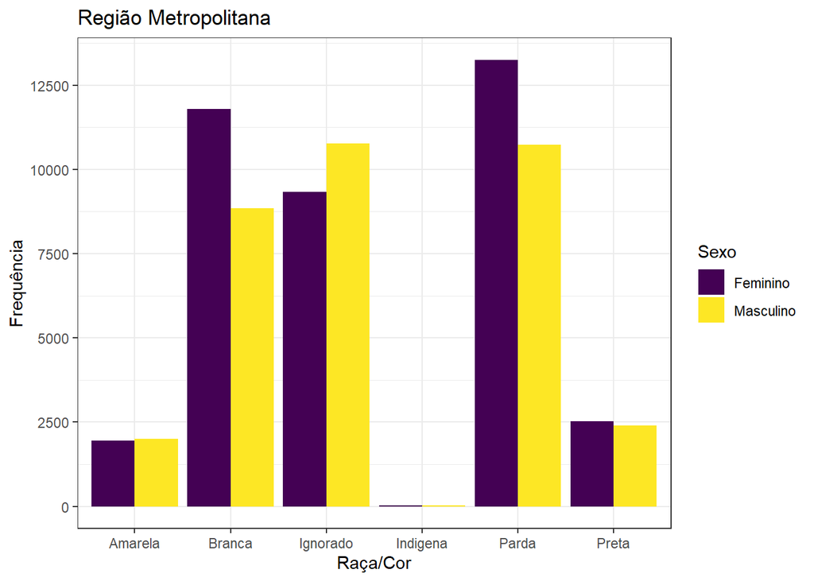

[figure not shown]

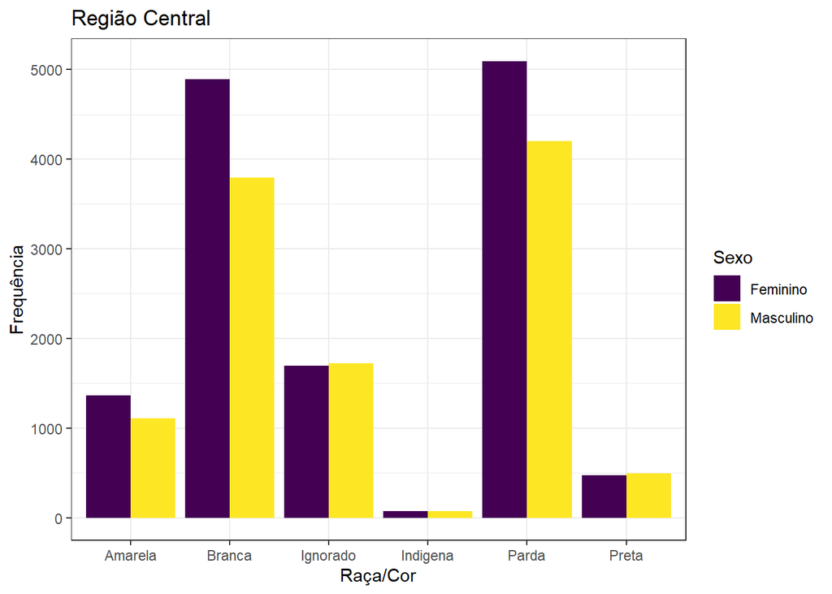

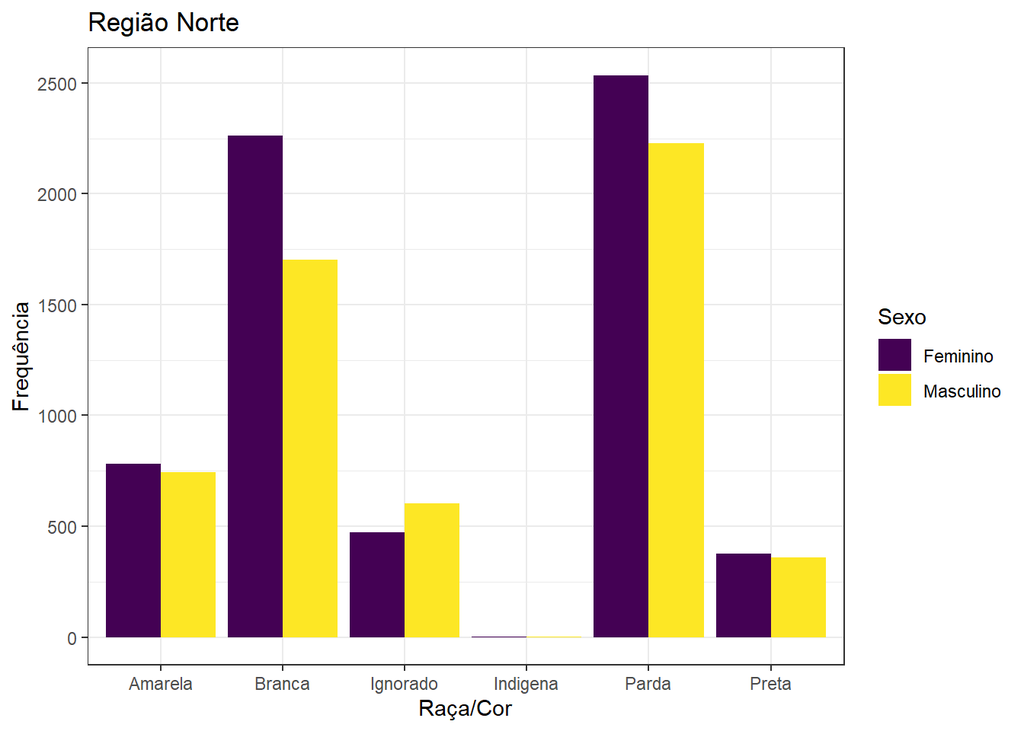

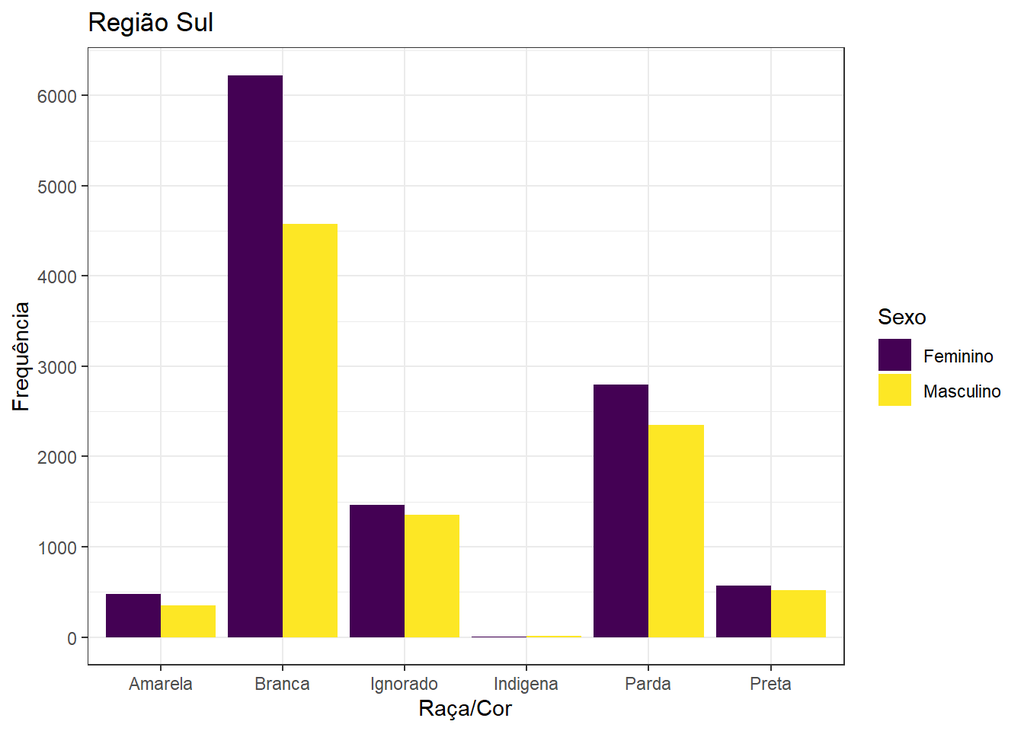

```r
regiao_m <- dados %>%
  filter(regiao == "Região Metropolitana",
         Sexo == "Masculino" | Sexo == "Feminino")

ggplot(regiao_m) +
  geom_bar(aes(RacaCor, fill = Sexo), position = "dodge") +
  scale_y_continuous(breaks = seq(0, 100000, 2500)) +
  labs(y = "Frequência", x = "Raça/Cor", title = "Região Metropolitana ") +
  theme_bw() +
  scale_fill_viridis_d()
```

Ao olharmos para os gráficos dessas regiões podemos tirar algumas conclusões. De forma geral, ao olharmos para a variável sexo, o feminino é maior em relação ao masculino em quase todas as situações com algumas exceções, como por exemplo, na raça classificada como “ignorado”. Se olharmos agora para a variável raça/cor, é visível que a classificação branca e parda aparecem muito mais em relação as outras, a raça indígina, apesar de frequente em todas as 4 regiões, tem uma presença muito pequena aparecendo mais na região central.

Agora queremos observar a distribuição dos casos, separados por sexo, ao longo do tempo.

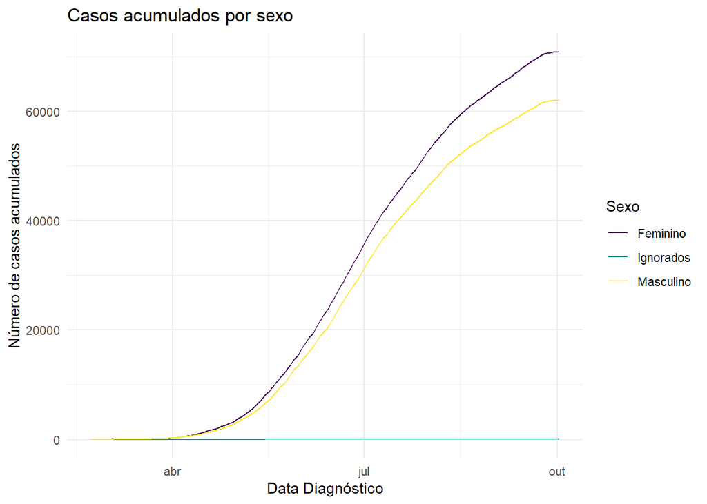

```r
dados <- dados %>%
  mutate(DataNotificacao = as.Date(DataDiagnostico))
casos_t <- dados %>%
  group_by(Sexo, DataNotificacao) %>%
  summarise(n_casos = n()) %>%
  tidyr::complete(
    tidyr::nesting(Sexo),
    DataNotificacao = seq.Date(min(dados$DataNotificacao),
                               max(dados$DataNotificacao),
                               by = "day"),
    fill = list(n_casos = 0)
  ) %>%
  mutate(casos_acumulados = cumsum(n_casos))
ggplot(casos_t) +
  theme_minimal() +
  aes(x = DataNotificacao, y = casos_acumulados, color = Sexo) +
  geom_line() +
  scale_color_viridis_d() +
  labs(y = "Número de casos acumulados",
       x = "Data Diagnóstico",
       title = "Casos acumulados por sexo")
```

Observando o gráfico de casos acumulados separado por sexo, podemos ver de forma mais clara o que foi dito antes, o sexo femino tem uma frequência consideravelmente maior em relação ao masculino e foi maior em todo o intervalo de tempo analisado.

Uma última coisa interessante a ser feita, é análisar a taxa de letalidade da COVID-19. Para fazer isso precisamos calcular essa taxa e separar com as variáveis que queremos exibir no gráfico.

Para fazer criamos um DataFrame chamado “casos” que vai agrupar as variáveis “RacaCor” e “Sexo” e fazer a contagem de casos confirmados. Depois, criamos um otro data frame com as mesmas variáveis, porém esse vai contar o número de mortes pela COVID-19. Por último, o DataFrame chamado “letalidade” foi responsável por calcular a taxa de letalidade da COVID-19. Vale ressaltar que a taxa de letalidade é a proporção entre o número de óbitos por uma doença em relação ao número de indivíduos acometidos por essa doença.

```r
casos <- dados %>%
  group_by(RacaCor, Sexo) %>%
  summarise(n_casos = n())
mortes <- dados %>%
  filter(Evolucao ==  "Óbito pelo COVID-19") %>%
  group_by(RacaCor, Sexo) %>%
  summarise(n_mortes = n())
letalidade <- inner_join(casos, mortes) %>%
  mutate(taxa_l =   ifelse(n_casos == 0, 0,
                           round(100 * n_mortes / n_casos, 1)))
```

Certo, por último iremos plotar o gráfico

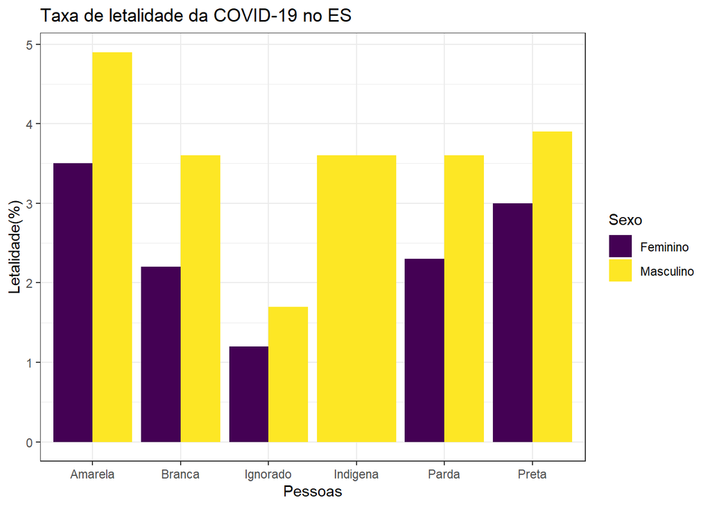

```r
ggplot(letalidade) + geom_col(aes(x = RacaCor, y = taxa_l, fill = Sexo), position = "dodge") +
  labs(x = "Pessoas",
       y = "Letalidade(%)",
       title = "Taxa de letalidade da COVID-19 no ES") +
  scale_fill_viridis_d() +
  theme_bw()
```